# 01_correlation

Profesora Carolina Luque

**Resultado de aprendizaje:** Analiza datos de diversa índole mediante técnicas de estadística descriptiva y probabilidad.

**Hito 3:** Regresión lineal y correlación.

**Temas:**

- Diagrama de dispersión
- Covarianza
- Coeficiente de correlación de Pearson
- Matriz de covarianza y correlación

```python
import pandas as pd
import matplotlib.pyplot as plt
from scipy import stats
import numpy as np
import seaborn as sns
```

# **Diagrama de dispersión**

El [diagrama de dispersión](https://es.wikipedia.org/wiki/Diagrama_de_dispersi%C3%B3n) es una **herramienta visual** que permite **explorar patrones entre dos variables cuantitativas**.

Facilita la observación de patrones de dependencia, tendencias lineales y no lineales, así como la identificación de posibles valores atípicos. Esta visualización constituye un paso inicial fundamental para evaluar la viabilidad de aplicar un modelo de regresión lineal para caracterizar la asociación entre las dos variables.

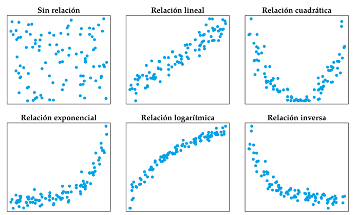

El diagrama de dispersión muestra **cada observación como un punto en un plano cartesiano**, donde el eje $x$ representa la **variable independiente** (regresor, predictor o variable explicativa) y el eje $y$ la **variable dependiente** (respuesta).

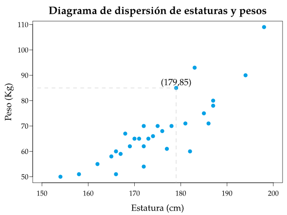

Si existe una relación lineal entre las dos variables, los puntos en el gráfico tenderán a agruparse alrededor de una recta. La pendiente de la recta proporciona una idea acerca del tipo de relación lineal: creciente o decreciente.

## **Ejemplo**

Este conjunto de datos contiene información sobre el total de la cuenta (X1), la edad del cliente (X2) y las propinas (y) en un restaurante.

```python
# variables: X1:total_bill, X2:edad, y:tip
df = pd.DataFrame({'X1': [10, 10, 20, 30, 40, 50, 60, 80, 100],
                   'X2': [35, 38, 38, 40, 41, 42, 50, 65, 60],
                   'y': [1.5,1.2,2.2,2.9,4.8,5.3,6,8.2,9]})

# seleccionamos las variables: total_bill como independiente, tip como dependiente
X = df['X1']
y = df['y']
```

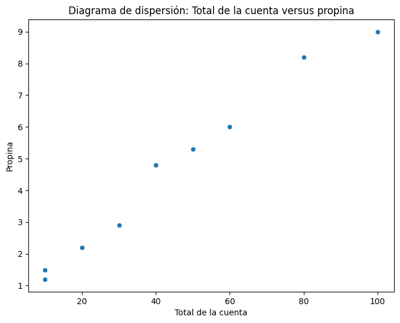

```python
# Diagrama de dispersión
plt.figure(figsize=(8, 6))
sns.scatterplot(x=X, y=y)
plt.title('Diagrama de dispersión: Total de la cuenta versus propina')
plt.xlabel('Total de la cuenta')
plt.ylabel('Propina')
plt.show()
```

En el gráfico cada punto representa de la cantidad total de la cuenta y la propina que deja un cliente.

El gráfico muestra una posible relación lineal entre el total de la cuenta (X1) y la propina (y). A medida que aumenta el total de la cuenta, también lo hace la propina, lo que sugiere una dependencia (relación o asociación) positiva entre ambas variables.

# **Covarianza**

La **covarianza** es un valor que indica el grado de variación conjunta de dos variables aleatorias respecto a sus medias.

La **covarianza muestral** del conjunto de datos bivariado $(x_1,y_1),(x_2,y_2),\ldots,(x_n,y_n)$, denotada con $COV(X,Y)$ o $s_{xy}$, se calcula como:

$$ COV(X,Y)=\frac{1}{n-1}\sum_{i=1}^{n} (x_i - \bar{x})(y_i - \bar{y}) $$

- Si $COV(X,Y) > 0$, $y$ tiende a aumentar cuando lo hace $x$ (relación directa).
- Si $COV(X,Y) < 0$, $y$ tiende a disminuir cuando lo hace $x$ (relación inversa).
- Si $COV(X,Y) \approx 0$, los puntos se reparten "equitativamente" alrededor de $(\bar{x},\bar{y})$.

## **Características**

- Es sensible a datos atípicos.
- Está dada en unidades mixtas de medición (unidades de la variable independiente multiplicadas por las unidades de la variable dependiente).
- Si la covarianza es aproximadamente cero, esto no quiere decir que no pueda existir una relación entre las variables.

## **Ejemplo**

*Paso 1*: Primero calculamos la media de $X$ y $y$:

$$ \bar{x} = \frac{1}{n} \sum_{i=1}^{n} X_i = \frac{10 + 10 + 20 + 30 + 40 + 50 + 60 + 80 + 100}{9} = \frac{400}{9} \approx 44.44 $$$$ \bar{y} = \frac{1}{n} \sum_{i=1}^{n} y_i = \frac{1.5 + 1.2 + 2.2 + 2.9 + 4.8 + 5.3 + 6 + 8.2 + 9}{9} = \frac{41.1}{9} \approx 4.57 $$

*Paso 2*: Cálculo de las diferencias $(x_i - \bar{x})$ y $(y_i - \bar{y})$

$$ x_i - \bar{x} = [10 - 44.44, 10 - 44.44, 20 - 44.44, 30 - 44.44, 40 - 44.44, 50 - 44.44, 60 - 44.44, 80 - 44.44, 100 - 44.44] = [-34.44, -34.44, -24.44, -14.44, -4.44, 5.56, 15.56, 35.56, 55.56] $$$$ y_i - \bar{y} = [1.5 - 4.57, 1.2 - 4.57, 2.2 - 4.57, 2.9 - 4.57, 4.8 - 4.57, 5.3 - 4.57, 6 - 4.57, 8.2 - 4.57, 9 - 4.57] = [-3.07, -3.37, -2.37, -1.67, 0.23, 0.73, 1.43, 3.63, 4.43] $$

*Paso 3*: Multiplicación de las diferencias $(x_i - \bar{x})$ y $(y_i - \bar{y})$

$$ (x_i - \bar{x})(y_i - \bar{y}) = [-34.44 \times -3.07, -34.44 \times -3.37, -24.44 \times -2.37, -14.44 \times -1.67, -4.44 \times 0.23, 5.56 \times 0.73, 15.56 \times 1.43, 35.56 \times 3.63, 55.56 \times 4.43] = [105.72, 116.05, 57.92, 24.12, -1.02, 4.06, 22.25, 129.05, 246.11] $$

*Paso 4*: Suma de los productos

$$ \sum_{i=1}^{n} (x_i - \bar{x})(y_i - \bar{y}) = 105.72 + 116.05 + 57.92 + 24.12 - 1.02 + 4.06 + 22.25 + 129.05 + 246.11 = 704.26 $$

*Paso 5*: División entre $n-1$

$$ \text{COV}(X, Y) = \frac{704.26}{9 - 1} = \frac{704.26}{8} = 88.03 $$

```python
# covarianza
covarianza = np.cov(X, y, bias=False)[0][1]  # bias=True divide por n, bias=False (por defecto) divide por n-1
print("Covarianza:", covarianza)
```

```
Covarianza: 88.04166666666667
```

Una covarianza "grande" indica que hay una relación de tipo lineal entre las dos variables. Pero, ¿qué significa que la covarianza sea "grande"?

La covarianza está dada en unidades mixtas de medición, lo que motiva definir una medida de la relación entre dos variables cuantitativas, que no se vea "afectada" por los cambios de unidad de medida, es decir, que sea adimensional.

# **Coeficiente de correlación de Pearson**

El coeficiente de correlación está ligado directamente con el grado de la **asociación lineal** de las variables. De hecho, el coeficiente de correlación únicamente caracteriza la fortaleza de la relación lineal entre dos variables cuantitativas.

El coeficiente de correlación siempre toma valores entre $-1$ y $1$:

- $r=1$: indica una correlación positiva perfecta. A medida que una variable aumenta, la otra también lo hace.
- $r=−1$: indica una correlación negativa perfecta. A medida que una variable aumenta, la otra también disminuye.
- $r=0$: Indica que no hay correlación lineal. No hay una relación lineal clara entre las variables.

## **Características**

- Únicamente toma valores entre $-1$ y $1$.
- Es sensible a datos atípicos.
- Es una medida adimensional.
- Tiene el mismo signo de la covarianza.

## **Ejemplo**

*Paso 1*: Cálculo de las desviaciones estándar

La desviación estándar de $X$ es:

$$ s_x = \sqrt{\frac{1}{n-1} \sum_{i=1}^{n} (x_i - \bar{x})^2} = \sqrt{\frac{1}{8} \left[(-34.44)^2 + (-34.44)^2 + (-24.44)^2 + (-14.44)^2 + (-4.44)^2 + (5.56)^2 + (15.56)^2 + (35.56)^2 + (55.56)^2\right]} = \sqrt{977.81} \approx 31.28 $$

La desviación estándar de $Y$ es:

$$ s_y = \sqrt{\frac{1}{8} \sum_{i=1}^{n} (y_i - \bar{y})^2} = \sqrt{\frac{1}{8} \left[(-3.07)^2 + (-3.37)^2 + (-2.37)^2 + (-1.67)^2 + (0.23)^2 + (0.73)^2 + (1.43)^2 + (3.63)^2 + (4.43)^2\right]} = \sqrt{\frac{64.60}{8}} = \sqrt{8.08} \approx 2.84 $$

*Paso 2*: Cálculo del coeficiente de correlación de Pearson

$$ r = \frac{\text{COV}(X, Y)}{s_x s_y} = \frac{88.03}{31.28 \times 2.84} = \frac{88.03}{88.83} \approx 0.99 $$

```python
# Coeficiente de correlación de Pearson
correlation_pearson = np.corrcoef(X, y)[0, 1]
print(f"Coeficiente de correlación de Pearson: {correlation_pearson}")
```

```
Coeficiente de correlación de Pearson: 0.9906715488399718
```

# **Prueba de hipótesis para el coeficiente de correlación de Pearson**

La **prueba de hipótesis para el coeficiente de correlación de Pearson** permite determinar si **existe evidencia suficiente para afirmar que hay una relación lineal significativa entre dos variables cuantitativas**.

El sistema de hipótesis en este caso es:

\begin{cases} H_0: & \rho = 0 \quad \text{No hay correlación lineal entre las dos variables.} \\ H_1: & \rho \neq 0 \quad \text{Hay correlación lineal entre las dos variables.} \end{cases}

$\rho$ es el coeficiente de correlación poblacional.

$$ \rho = \frac{\text{Cov}(X, Y)}{\sigma_X \sigma_Y} $$

El **estadístico de prueba** para esta prueba es:

$$ t = \frac{r \sqrt{n-2}}{\sqrt{1-r^2}} $$

Este estadístico sigue una [distribución t de Student](https://es.wikipedia.org/wiki/Distribuci%C3%B3n_t_de_Student) con $n - 2$ grados de libertad. En la estimación de $\rho$ se estiman dos parámetros ($\mu_{X}$ y $\mu_{Y}$) a partir de $n$ observaciones.

```python
# calcular el coeficiente de correlación de Pearson (opción 2)
correlation_coefficient, p_value = stats.pearsonr(X, y)

# mostrar resultados
print(f'Coeficiente de correlación de Pearson: {correlation_coefficient:.4f}')
print(f'Valor p: {p_value:.4f}')

# prueba de hipótesis
alpha = 0.05  # Nivel de significancia
if p_value < alpha:
    print("Se rechaza la hipótesis nula.\nHay evidencia suficiente para afirmar que existe una correlación lineal significativa entre las dos variables cuantitativas.")
else:
    print("No se rechaza la hipótesis nula.\nNo hay evidencia suficiente para afirmar que existe una correlación lineal significativa entre las dos variables cuantitativas.")
```

```
Coeficiente de correlación de Pearson: 0.9907
Valor p: 0.0000
Se rechaza la hipótesis nula.
Hay evidencia suficiente para afirmar que existe una correlación lineal significativa entre las dos variables cuantitativas.
```

# **Matriz de covarianza y matriz de correlación**

La **matriz de covarianza**, $\mathbf{\Sigma}$, es una matriz simétrica que contiene la covarianza entre pares de elementos de un vector aleatorio. De manera formal si $\mathbf{X}$ es un vector aleatorio dado por

$$ \mathbf{X} = \begin{bmatrix} X_1 \\ \vdots \\ X_n \end{bmatrix} $$

Si la $i$-ésima entrada del vector $\mathbf{X}$ es una \textit{variable aleatoria} con varianza finita, entonces la matriz de covarianza $\mathbf{\Sigma}$ es una matriz de dimensión $n \times n$ cuya entrada $(i,j)$ es la covarianza entre la variable $X_i$ y $X_j$, es decir

$$ \Sigma_{ij} = \text{Cov}(X_i, X_j) $$

En particular, cuando $i = j$, se tiene

$$ \Sigma_{ii} = \text{Cov}(X_i, X_i) = \text{Var}(X_i) $$

Luego, la matriz $\mathbf{\Sigma}$ queda definida como

$$ \mathbf{\Sigma} = \begin{bmatrix} \text{Var}(X_1) & \text{Cov}(X_1, X_2) & \cdots & \text{Cov}(X_1, X_n) \\ \text{Cov}(X_2, X_1) & \text{Var}(X_2) & \cdots & \text{Cov}(X_2, X_n) \\ \vdots & \vdots & \ddots & \vdots \\ \text{Cov}(X_n, X_1) & \text{Cov}(X_n, X_2) & \cdots & \text{Var}(X_n) \end{bmatrix} $$

```python
# matriz de covarianzas
cov_matrix = df.cov()
print("Matriz de Covarianzas:")
print(cov_matrix)
```

```
Matriz de Covarianzas:
            X1          X2          y
X1  977.777778  306.527778  88.041667
X2  306.527778  112.027778  27.791667
y    88.041667   27.791667   8.077500
```

La **matriz de correlación** es una matriz simétrica de dimensión $n \times n$ que contiene el coeficiente de correlación entre pares de elementos de un vector aleatorio.

```python
# matriz de correlaciones
correlation_matrix = df.corr()
print("\nMatriz de Correlaciones:")
print(correlation_matrix)
```

```
Matriz de Correlaciones:
          X1        X2         y
X1  1.000000  0.926162  0.990672
X2  0.926162  1.000000  0.923875
y   0.990672  0.923875  1.000000
```

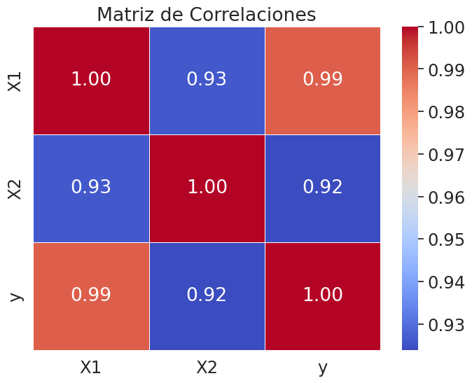

```python
# mapa de calor
plt.figure(figsize=(8, 6))
sns.heatmap(correlation_matrix, annot=True, cmap='coolwarm', fmt='.2f', linewidths=0.5)
plt.title('Matriz de Correlaciones')
plt.show()
```

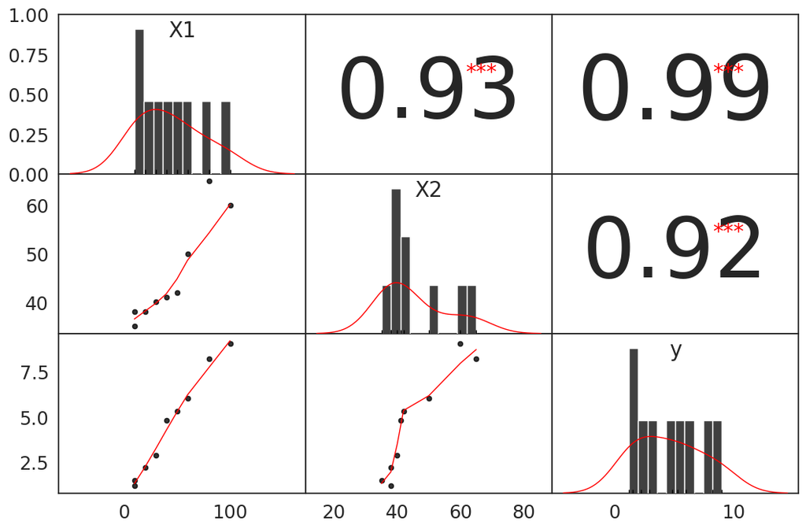

```python
# matriz de dispersión

# Función para mostrar la correlación
def corrdot(x, y, **kwargs):
    corr_r = x.corr(y)
    corr_text = round(corr_r, 2)
    ax = plt.gca()
    font_size = abs(corr_r) * 80 + 5
    ax.annotate(corr_text, [.5, .5], xycoords="axes fraction",
                ha='center', va='center', fontsize=font_size)

# función para mostrar estrellas de significancia
def corrfunc(x, y, **kwargs):
    r, p = stats.pearsonr(x, y)
    p_stars = ''
    if p <= 0.001:
        p_stars = '***'
    elif p <= 0.01:
        p_stars = '**'
    elif p <= 0.05:
        p_stars = '*'
    ax = plt.gca()
    ax.annotate(p_stars, xy=(0.65, 0.6), xycoords=ax.transAxes,
                color='red', fontsize=20)

# configura el PairGrid
g = sns.PairGrid(df, aspect=1.5, diag_sharey=False, despine=False)
g.map_lower(sns.regplot, lowess=True, ci=False,
            line_kws={'color': 'red', 'lw': 1},
            scatter_kws={'color': 'black', 's': 20})
g.map_diag(sns.histplot, color='black', bins=10, stat='density')  # Cambié a 'density'
g.map_diag(sns.kdeplot, color='red', lw=1)  # Agrega KDE en el diagonal
g.map_diag(sns.rugplot, color='black')
g.map_upper(corrdot)
g.map_upper(corrfunc)
g.fig.subplots_adjust(wspace=0, hspace=0)

# eliminar etiquetas de los ejes
for ax in g.axes.flatten():
    ax.set_ylabel('')
    ax.set_xlabel('')

# añadir títulos a los ejes diagonales
for ax, col in zip(np.diag(g.axes), df.columns):
    ax.set_title(col, y=0.82, fontsize=20)

plt.show()
```

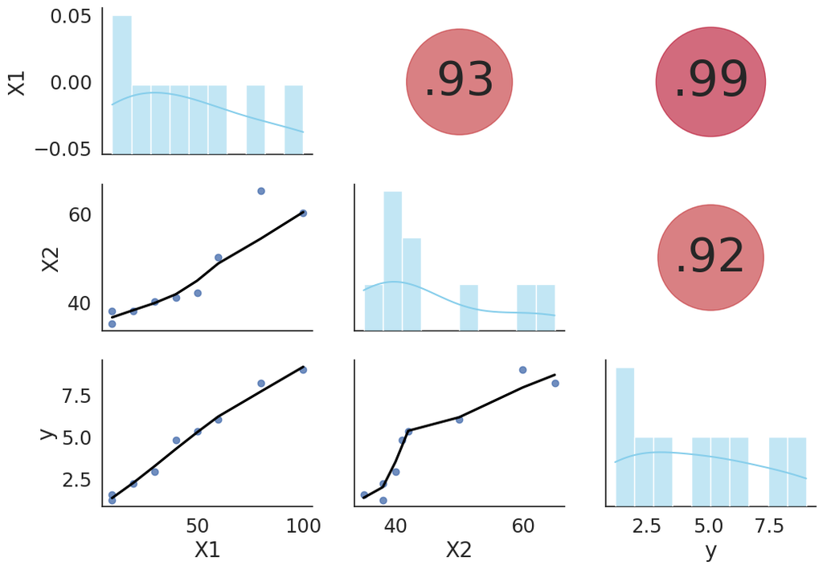

```python
# gráfico de burbujas

# función para mostrar la correlación
def corrdot(x, y, **kwargs):
    corr_r = x.corr(y, 'pearson')
    corr_text = f"{corr_r:2.2f}".replace("0.", ".")
    ax = plt.gca()
    ax.set_axis_off()
    marker_size = abs(corr_r) * 10000
    ax.scatter([.5], [.5], s=marker_size, c=[corr_r], alpha=0.6, cmap="coolwarm",
               vmin=-1, vmax=1, transform=ax.transAxes)
    font_size = abs(corr_r) * 40 + 5
    ax.annotate(corr_text, [.5, .5], xycoords="axes fraction",
                ha='center', va='center', fontsize=font_size)

# estilo de seaborn
sns.set(style='white', font_scale=1.6)


# configura el PairGrid
g = sns.PairGrid(df, aspect=1.4, diag_sharey=False)
g.map_lower(sns.regplot, lowess=True, ci=False, line_kws={'color': 'black'})
g.map_diag(sns.histplot, kde=True, color='skyblue', bins=10)  # Cambié el color a azul cielo
g.map_upper(corrdot)

plt.show()
```

## **Ejemplo: pingüinos**

El conjunto datos de `pingüinos` que viene precargado en la librería `Seaborn`. En este conjunto encontramos información de tres tipos de especies:

- `bill_length_mm`: longitud del pico en milímetros
- `bill_depth_mm`: profunidad del pico en milímetros
- `flipper_length_mm`: longitud de las alas en milímetros
- `body_mass_g`: masa corporal en gramos

```python
df = sns.load_dataset("penguins")
df.head()
```

|  | species | island | bill_length_mm | bill_depth_mm | flipper_length_mm | body_mass_g | sex |
| --- | --- | --- | --- | --- | --- | --- | --- |
| 0 | Adelie | Torgersen | 39.1 | 18.7 | 181.0 | 3750.0 | Male |
| 1 | Adelie | Torgersen | 39.5 | 17.4 | 186.0 | 3800.0 | Female |
| 2 | Adelie | Torgersen | 40.3 | 18.0 | 195.0 | 3250.0 | Female |
| 3 | Adelie | Torgersen | NaN | NaN | NaN | NaN | NaN |
| 4 | Adelie | Torgersen | 36.7 | 19.3 | 193.0 | 3450.0 | Female |

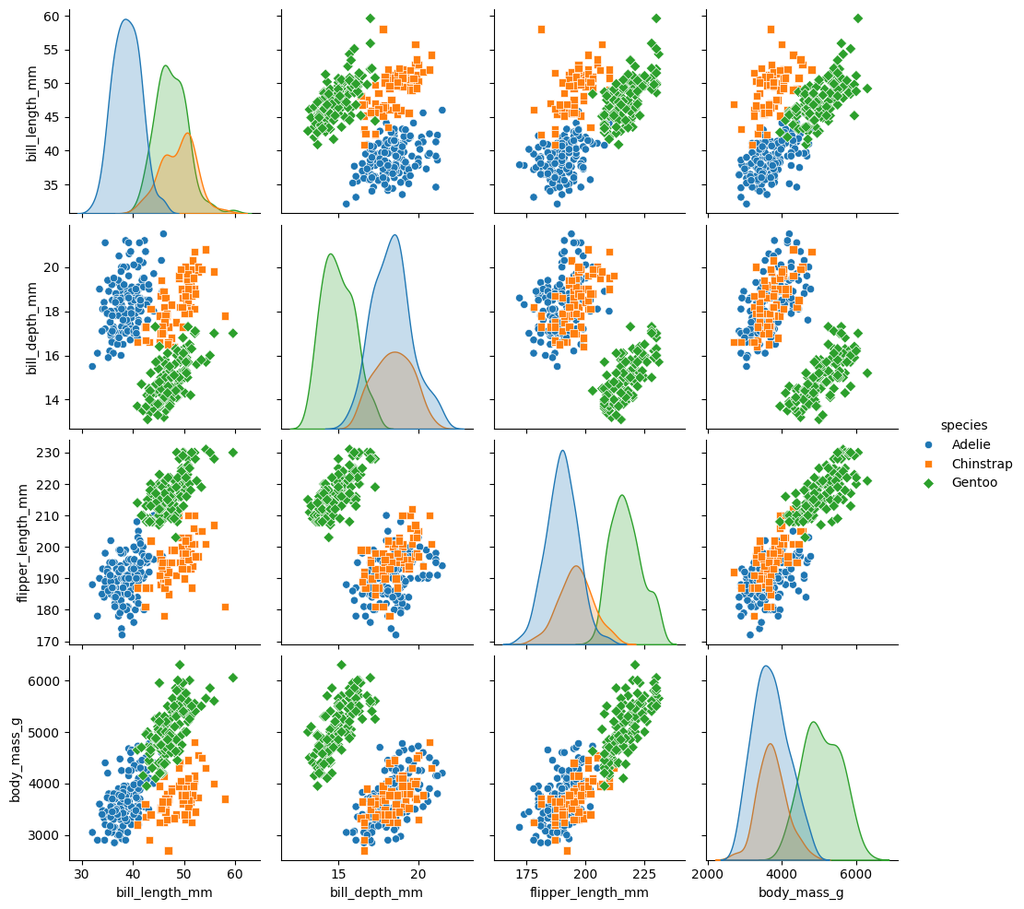

```python
sns.pairplot(df, hue="species", markers=["o", "s", "D"])
```

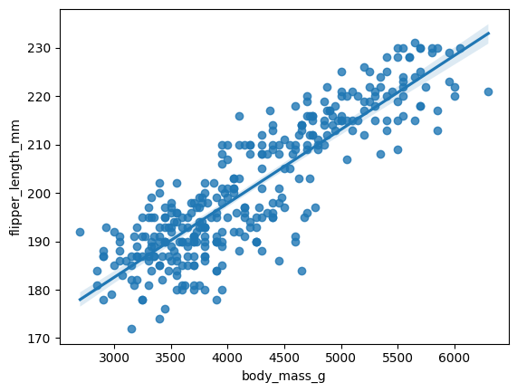

```python
sns.regplot(x=df["body_mass_g"], y=df["flipper_length_mm"])
```

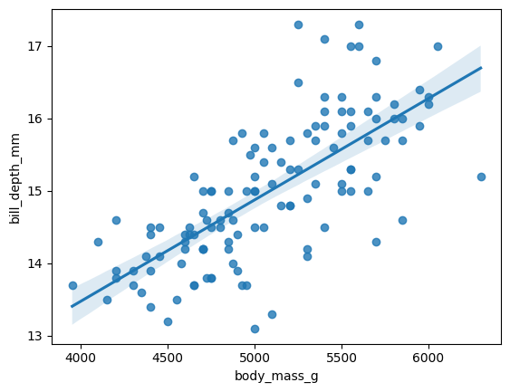

```python
# filtrar las filas donde la especie es 'Gentoo'
gentoo_data = df[df['species'] == 'Gentoo']

# crear el gráfico de regresión con las columnas numéricas
sns.regplot(x=gentoo_data['body_mass_g'], y=gentoo_data['bill_depth_mm'])
```

# **Ejercicio (Opcional): viviendas California**

El conjunto de datos California Housing proviene del censo de 1990 de los Estados Unidos. Se recopiló información sobre diferentes bloques de viviendas en California. Un "bloque" es la unidad geográfica más pequeña utilizada por el censo, que puede representar una manzana de una ciudad o una pequeña área rural.

Este conjunto de datos es frecuentemente utilizado para estudiar problemas de regresión, en particular para predecir el valor medio de una vivienda en función de diversas características socioeconómicas y físicas de la región.

El conjunto de datos incluye las siguientes variables:

- MedInc: ingreso medio.
- HouseAge: edad de las casas.
- AveRooms: promedio de habitaciones.
- AveBedrms: promedio de dormitorios.
- Population: población.
- AveOccup: promedio de ocupantes
- Latitude: latitud.
- Longitude: longitud.
- MedHouseVal: valor medio de la casa.

Utilizando este conjunto de datos realice los siguientes ejercicios.

- Cargar el conjunto de datos

```
from sklearn.datasets import fetch_california_housing

# cargar el conjunto de datos California Housing
data = fetch_california_housing()
df = pd.DataFrame(data.data, columns=data.feature_names)

# añadir la columna del valor medio de la casa (target)
df['MedHouseVal'] = data.target

# visualizar las primeras filas
print(df.head())
```

- Trazar un diagrama de dispersión entre `MedInc` y `MedHouseVal`.
- Calcular la covarianza y el coeficiente de correlación lineal de Pearson entre `MedInc` y `MedHouseVal`.
- Implementar e interpretar una prueba de hipótesis para el coeficiente de correlación lineal de Pearson entre `MedInc` y `MedHouseVal`.
- Visualizar la matriz de correlación con todas las variables numéricas del conjunto de datos.

# **Referencias**

- Rajagopalan, G. (2021). A Python Data Analyst's Toolkit: Learn Python and Python-based Libraries with Applications in Data Analysis and Statistics. Springer.
- Igual, L. and Seguí, S. (2017). Introduction to Data Science A Python Approach to Concepts, Techniques and Applications. Springer.
- Haslwanter, T. (2016). An Introduction to Statistics with Python With Applications in the Life Sciences. Springer.